# LAs_clusters k = 9

18 March, 2021, 14:43

## furlough

```r
url <- "https://assets.publishing.service.gov.uk/government/uploads/system/uploads/attachment_data/file/891607/Coronavirus_Job_Retention_Scheme_Statistics_Tables_June_2020.xlsx"
GET(url, write_disk(tf <- tempfile(fileext = ".xlsx")))
```

```
## Response [https://assets.publishing.service.gov.uk/government/uploads/system/uploads/attachment_data/file/891607/Coronavirus_Job_Retention_Scheme_Statistics_Tables_June_2020.xlsx]
##   Date: 2021-03-18 14:44
##   Status: 200
##   Content-Type: application/vnd.openxmlformats-officedocument.spreadsheetml.sheet
##   Size: 105 kB
## <ON DISK>  C:\Users\nw19521\AppData\Local\Temp\RtmpMnzZRZ\file392878468ad.xlsx
```

```r
f <- readxl::read_excel(tf, 6L, range = "B7:D486", col_names = F) %>%
  rename(lad19cd = 1,
         lad19nm = 2,
         furlough = 3) %>%
  filter(!is.na(furlough) & !is.na(lad19cd)) %>%
  dplyr::select(-lad19nm)
```

```
## * `` -> ...1
## * `` -> ...2
## * `` -> ...3
```

## Load socio-econ data and merge

```r
data.old.path <- paste0(path, "/data/temp/data_for_aux.csv")
data <- read_csv(data.old.path) %>%
  dplyr::select(-c(1,4:19)) %>%
  left_join(x = lad, y = . ) %>%
  left_join(x = ., y = f )
# NOT RUN
# export file for future reference / backup
# data.out.path <- paste0(path, "/data/temp/data_for_aux_k9.csv")
# write.csv(data, data.out.path)
```

## Descriptive statistics and correlations

There is surprisingly low correlation between upload and download, morning and night. Number of tests are the most correlated variables.

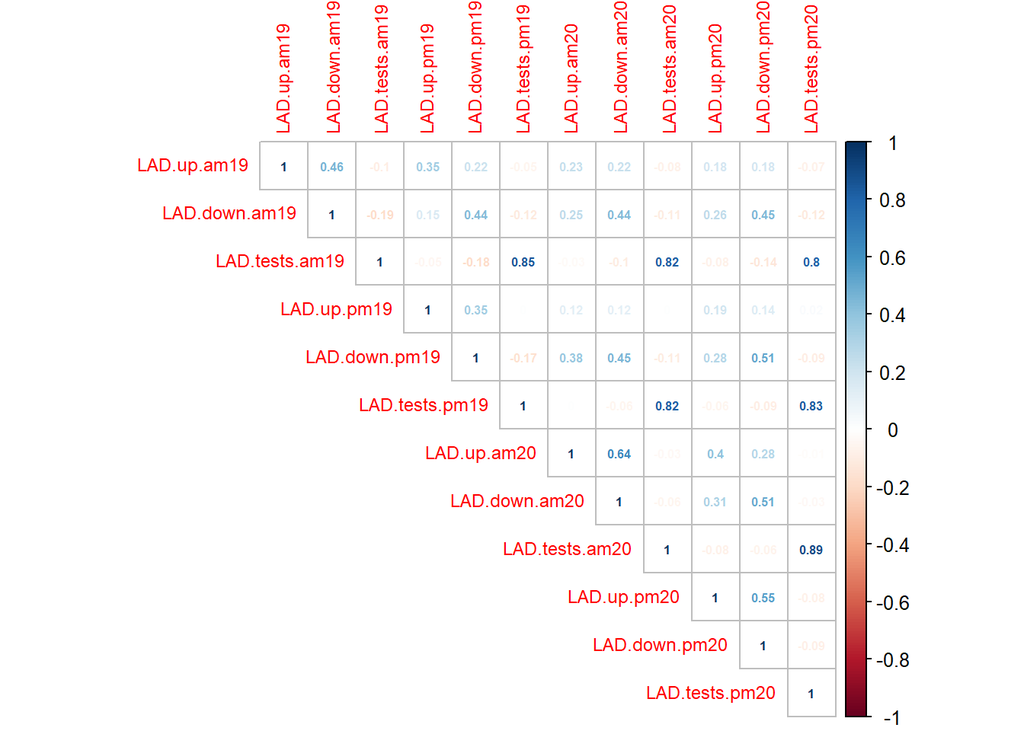

```r
data.cor <- data %>%
  dplyr::select(LAD.up.am19, LAD.down.am19,
                LAD.tests.am19, LAD.up.pm19,
                LAD.down.pm19, LAD.tests.pm19,
                LAD.up.am20, LAD.down.am20,
                LAD.tests.am20, LAD.up.pm20,
                LAD.down.pm20, LAD.tests.pm20)

m <- cor(data.cor)
corrplot(m, type="upper",method = "number", number.cex = .5, tl.cex = .75)
```

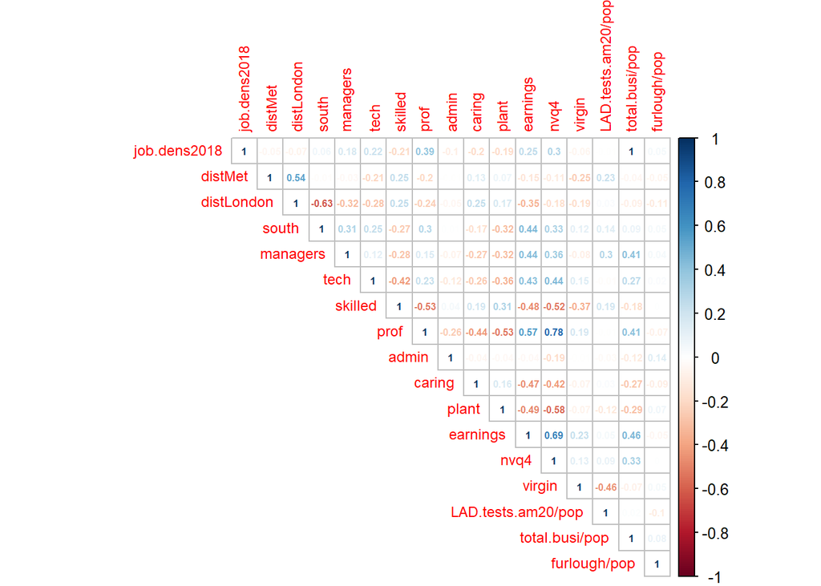

```r
# data.cor <- data %>%
#   dplyr::select(LAD.tests.am20,
#                 pop, pop16_64,
#                 managers, tech,
#                 skilled, earnings,
#                 total.busi)


data.cor <- data %>%
  dplyr::select(#pop16_64,
                pop,
                #pop.dens,
                job.dens2018,
                distMet,
                distLondon,
                south,
                managers,
                tech,
                skilled,
                prof,
                admin,
                caring,
                plant,
                earnings,
                total.busi,
                nvq4,
                furlough,
                LAD.tests.am20,
                virgin) %>%
  mutate('LAD.tests.am20/pop' = LAD.tests.am20/pop) %>%
  mutate('total.busi/pop' = total.busi/pop) %>%
  mutate('furlough/pop' = furlough/pop) %>%
  dplyr::select(-LAD.tests.am20,-pop, -total.busi, -furlough)


m <- cor(data.cor, use = "pairwise.complete.obs")
corrplot(m, type="upper",method = "number", number.cex = .5, tl.cex = .75)
```

```r
stargazer(data.cor,
          type="html",
          #type="text",
          summary = T,
          nobs = T)
```

| Statistic | N | Mean | St. Dev. | Min | Pctl(25) | Pctl(75) | Max |
| --- | --- | --- | --- | --- | --- | --- | --- |
| job.dens2018 | 365 | 1.137 | 5.726 | 0.400 | 0.700 | 0.930 | 110.110 |
| distMet | 365 | 53.269 | 57.700 | 0.150 | 22.050 | 69.290 | 544.090 |
| distLondon | 365 | 201.558 | 173.634 | 0.150 | 76.180 | 278.880 | 1,003.950 |
| south | 365 | 0.463 | 0.499 | 0.000 | 0.000 | 1.000 | 1.000 |
| managers | 363 | 12.009 | 4.013 | 3.600 | 9.000 | 14.300 | 27.900 |
| tech | 364 | 14.505 | 4.057 | 3.500 | 11.800 | 16.900 | 29.600 |
| skilled | 358 | 10.513 | 3.764 | 1.000 | 8.025 | 12.500 | 21.600 |
| prof | 364 | 21.223 | 6.902 | 4.400 | 16.775 | 24.850 | 71.600 |
| admin | 359 | 9.965 | 2.738 | 3.200 | 8.100 | 11.400 | 21.300 |
| caring | 362 | 9.261 | 2.827 | 2.800 | 7.300 | 11.400 | 17.800 |
| plant | 337 | 6.339 | 2.847 | 1.200 | 4.400 | 7.900 | 19.800 |
| earnings | 360 | 592.184 | 81.129 | 437.600 | 534.625 | 633.875 | 893.200 |
| nvq4 | 365 | 39.329 | 11.076 | 15.000 | 31.800 | 45.300 | 100.000 |
| virgin | 381 | 0.150 | 0.140 | 0.000 | 0.018 | 0.238 | 0.753 |
| LAD.tests.am20/pop | 365 | 0.0005 | 0.0002 | 0.0001 | 0.0003 | 0.001 | 0.001 |
| total.busi/pop | 365 | 0.057 | 0.164 | 0.023 | 0.038 | 0.056 | 3.174 |
| furlough/pop | 362 | 0.115 | 0.013 | 0.077 | 0.107 | 0.122 | 0.178 |

## Auxiliary regression, dep. var.: upload clusters

```r
# helpful sources: http://www.princeton.edu/~otorres/LogitR101.pdf
# https://thestatsgeek.com/2014/02/08/r-squared-in-logistic-regression/

# convert dependent variable to factor
data$cluster.up <- as.factor(data$cluster.up)
data$cluster.up <- relevel(data$cluster.up, "4") # base category: cluster 4

aux.up.v1 <- multinom(cluster.up ~
                     #pop16_64 + # non sign, while pop is
                     pop +
                     #pop.dens +
                     job.dens2018 + # pop.dens is still insignificant when job.dens is excluded
                     distMet + distLondon + south +
                     managers + tech + skilled + prof + admin + caring + plant +
                     earnings + I(total.busi/pop) + nvq4 + I(furlough/pop) +
                     I(LAD.tests.am20/pop) + # non sensitive to addition of other tests pm
                     virgin
                   , data = data,
                   trace = F) # to avoid messages

# McFadden's R squared
aux.up.v1.null <- multinom(cluster.up ~ 1, data = data)
```

# weights: 18 (8 variable)

initial value 837.142564 iter 10 value 406.254340 iter 20 value 402.562154 iter 30 value 402.529544 iter 30 value 402.529544 iter 30 value 402.529544 final value 402.529544 converged

```r
r2.up.v1 <- 1-logLik(aux.up.v1)/logLik(aux.up.v1.null)

n.obs <- dim(aux.up.v1$fitted.values)[1]

stargazer(aux.up.v1,
          type = "html",
          #type = "text",
          nobs = T,
          digits = 3,
          covariate.labels=c(#"pop. 16-64, 2018",
            "pop, 2018",
            #"pop. density, 2018",
            "job density, 2018",
            "distance to nearest met. area",
            "distance to London",
            "South of the UK",
            "% of managerial jobs, 2020",
            "% of tech jobs, 2020",
            "% of skilled trade jobs, 2020",
            "% of professional jobs, 2020",
            "% of administrative jobs, 2020",
            "% of leisure jobs, 2020",
            "% of machine operation jobs, 2020",
            "earnings, 2019",
            "n. business est. per hab., 2019",
            "% of NVQ4+",
            "% furloughed pop., 2020",
            "n. of AM broadband tests per hab., 2020",
            "% of Virgin Media connections"),
          add.lines = list(c("McFadden's R squared",
                             round(r2.up.v1[1],3), round(r2.up.v1[1],3), round(r2.up.v1[1],3),
                             round(r2.up.v1[1],3), round(r2.up.v1[1],3), round(r2.up.v1[1],3),
                             round(r2.up.v1[1],3), round(r2.up.v1[1],3), round(r2.up.v1[1],3)
                             , round(r2.up.v1[1],3), round(r2.up.v1[1],3)),
                           (c("N",
                              n.obs, n.obs, n.obs,
                              n.obs, n.obs, n.obs,
                              n.obs, n.obs, n.obs
                              , n.obs, n.obs))))
```

*Dependent variable:*

1

2

3

5

6

7

8

9

(1)

(2)

(3)

(4)

(5)

(6)

(7)

(8)

pop, 2018

-0.00004**

0.00002**

0.00001

0.00001

0.00001

0.00001

-0.00001

0.00001

(0.00001)

(0.00001)

(0.00001)

(0.00002)

(0.00001)

(0.00001)

(0.00002)

(0.00001)

job density, 2018

-1.205***

0.121***

2.732***

0.451***

2.644***

-4.166***

-3.536***

2.114***

(0.00000)

(0.00000)

(0.00000)

(0.00000)

(0.00000)

(0.00000)

(0.00000)

(0.00000)

distance to nearest met. area

-0.019***

0.021***

-0.013***

0.007***

-0.017***

-0.134***

-0.018***

-0.022***

(0.0005)

(0.0003)

(0.0004)

(0.0003)

(0.002)

(0.0001)

(0.0003)

(0.002)

distance to London

0.013***

-0.006***

0.008***

-0.002**

0.014***

0.019***

0.012***

0.012***

(0.001)

(0.001)

(0.002)

(0.001)

(0.001)

(0.001)

(0.002)

(0.001)

South of the UK

-2.981***

-0.435***

3.899***

-6.024***

3.869***

2.347***

-1.307***

2.468***

(0.000)

(0.00000)

(0.00000)

(0.00000)

(0.00001)

(0.00000)

(0.00000)

(0.00001)

% of managerial jobs, 2020

1.190***

0.509***

0.948***

0.271***

0.977***

0.430***

1.012***

0.873***

(0.00003)

(0.00003)

(0.00003)

(0.00003)

(0.00003)

(0.00003)

(0.00002)

(0.00002)

% of tech jobs, 2020

0.199***

-0.189***

-0.124***

0.053***

-0.025***

-0.184***

-0.018***

-0.098***

(0.00003)

(0.00003)

(0.00003)

(0.00004)

(0.00003)

(0.00005)

(0.00003)

(0.00003)

% of skilled trade jobs, 2020

0.472***

0.270***

0.274***

-0.221***

0.332***

0.912***

0.311***

0.140***

(0.00002)

(0.00004)

(0.00004)

(0.00004)

(0.0001)

(0.0001)

(0.00003)

(0.00005)

% of professional jobs, 2020

-0.191***

-0.693***

-0.169***

-0.239***

-0.137***

-0.600***

-0.138***

-0.259***

(0.00003)

(0.00003)

(0.00004)

(0.0001)

(0.0001)

(0.0001)

(0.00005)

(0.00005)

% of administrative jobs, 2020

0.162***

-1.187***

0.016***

0.098***

-0.074***

0.034***

0.096***

-0.103***

(0.00002)

(0.00002)

(0.00002)

(0.00002)

(0.00002)

(0.00005)

(0.00002)

(0.00002)

% of leisure jobs, 2020

-0.186***

-0.105***

-0.623***

-1.226***

-0.627***

-0.827***

-0.717***

-0.671***

(0.00002)

(0.00003)

(0.00003)

(0.00002)

(0.00003)

(0.00003)

(0.00003)

(0.00003)

% of machine operation jobs, 2020

-0.256***

-0.015***

-0.061***

-0.848***

-0.208***

-0.594***

-0.137***

-0.288***

(0.00001)

(0.00003)

(0.00002)

(0.00002)

(0.00002)

(0.00002)

(0.00001)

(0.00002)

earnings, 2019

-0.001

0.032***

0.008***

0.056***

0.011***

0.031***

-0.0001

0.017***

(0.001)

(0.002)

(0.001)

(0.002)

(0.001)

(0.002)

(0.001)

(0.001)

14. business est. per hab., 2019

0.845***

-0.129***

0.301***

0.131***

0.454***

0.733***

-0.650***

-1.949***

(0.00000)

(0.00000)

(0.00000)

(0.00000)

(0.00000)

(0.00000)

(0.00000)

(0.00000)

% of NVQ4+

-0.181***

-0.120***

-0.137***

-0.447***

-0.162***

-0.164***

0.021***

-0.166***

(0.0001)

(0.0001)

(0.0001)

(0.0001)

(0.0001)

(0.0001)

(0.0001)

(0.0001)

% furloughed pop., 2020

-0.805***

-0.032***

5.259***

0.351***

-13.853***

0.959***

2.131***

6.055***

(0.00000)

(0.00000)

(0.00000)

(0.00000)

(0.00000)

(0.00000)

(0.00000)

(0.00000)

14. of AM broadband tests per hab., 2020

0.001***

-0.005***

-0.068***

0.008***

0.113***

0.003***

-0.013***

-0.040***

(0.000)

(0.000)

(0.000)

(0.000)

(0.000)

(0.000)

(0.000)

(0.000)

% of Virgin Media connections

-0.414***

6.166***

4.498***

-0.005***

0.094***

-8.949***

-3.075***

4.212***

(0.00000)

(0.00000)

(0.00000)

(0.00000)

(0.00000)

(0.00000)

(0.00000)

(0.00000)

Constant

-2.202***

-0.356***

-3.106***

2.213***

-0.345***

1.687***

-0.573***

2.581***

(0.00000)

(0.00000)

(0.00000)

(0.00000)

(0.00000)

(0.00000)

(0.00000)

(0.00000)

McFadden’s R squared

0.424

0.424

0.424

0.424

0.424

0.424

0.424

0.424

N

321

321

321

321

321

321

321

321

Akaike Inf. Crit.

767.901

767.901

767.901

767.901

767.901

767.901

767.901

767.901

*Note:*

p<0.1; p<0.05; p<0.01

## Auxiliary regression, dep. var.: upload clusters, NO NVQ4

```r
# helpful sources: http://www.princeton.edu/~otorres/LogitR101.pdf
# https://thestatsgeek.com/2014/02/08/r-squared-in-logistic-regression/

# convert dependent variable to factor
data$cluster.up <- as.factor(data$cluster.up)
data$cluster.up <- relevel(data$cluster.up, "4") # base category: cluster 4

aux.up <- multinom(cluster.up ~
                     #pop16_64 + # non sign, while pop is
                     pop +
                     #pop.dens +
                     job.dens2018 + # pop.dens is still insignificant when job.dens is excluded
                     distMet + distLondon + south +
                     managers + tech + skilled + prof + admin + caring + plant +
                     earnings + I(total.busi/pop) + I(furlough/pop) +
                     I(LAD.tests.am20/pop) + # non sensitive to addition of other tests pm
                     virgin
                   , data = data,
                   trace = F) # to avoid messages

# McFadden's R squared
aux.up.null <- multinom(cluster.up ~ 1, data = data)
```

# weights: 18 (8 variable)

initial value 837.142564 iter 10 value 406.254340 iter 20 value 402.562154 iter 30 value 402.529544 iter 30 value 402.529544 iter 30 value 402.529544 final value 402.529544 converged

```r
r2.up <- 1-logLik(aux.up)/logLik(aux.up.null)

n.obs <- dim(aux.up$fitted.values)[1]

stargazer(aux.up,
          type = "html",
          #type = "text",
          nobs = T,
          digits = 3,
          covariate.labels=c(#"pop. 16-64, 2018",
            "pop, 2018",
            #"pop. density, 2018",
            "job density, 2018",
            "distance to nearest met. area",
            "distance to London",
            "South of the UK",
            "% of managerial jobs, 2020",
            "% of tech jobs, 2020",
            "% of skilled trade jobs, 2020",
            "% of professional jobs, 2020",
            "% of administrative jobs, 2020",
            "% of leisure jobs, 2020",
            "% of machine operation jobs, 2020",
            "earnings, 2019",
            "n. business est. per hab., 2019",
            "% furloughed pop., 2020",
            "n. of AM broadband tests per hab., 2020",
            "% of Virgin Media connections"),
          add.lines = list(c("McFadden's R squared",
                             round(r2.up[1],3), round(r2.up[1],3), round(r2.up[1],3),
                             round(r2.up[1],3), round(r2.up[1],3), round(r2.up[1],3),
                             round(r2.up[1],3), round(r2.up[1],3), round(r2.up[1],3)
                             , round(r2.up[1],3), round(r2.up[1],3)),
                           (c("N",
                              n.obs, n.obs, n.obs,
                              n.obs, n.obs, n.obs,
                              n.obs, n.obs, n.obs
                              , n.obs, n.obs))))
```

*Dependent variable:*

1

2

3

5

6

7

8

9

(1)

(2)

(3)

(4)

(5)

(6)

(7)

(8)

pop, 2018

-0.00004**

0.00002

0.00001

0.00002

0.00001

0.00002

-0.00000

0.00001

(0.00002)

(0.00001)

(0.00001)

(0.00002)

(0.00001)

(0.00001)

(0.00002)

(0.00001)

job density, 2018

-0.534***

-0.362***

4.211***

-0.890***

3.516***

-8.624***

-3.259***

3.337***

(0.00000)

(0.00000)

(0.00000)

(0.00000)

(0.00000)

(0.00000)

(0.00000)

(0.00000)

distance to nearest met. area

-0.007***

0.013***

0.002***

0.023***

-0.001

-0.158***

0.005***

-0.003**

(0.0004)

(0.00001)

(0.0003)

(0.0002)

(0.002)

(0.0001)

(0.0003)

(0.002)

distance to London

0.011***

0.004***

0.005**

-0.013***

0.010***

0.012***

0.008***

0.008***

(0.001)

(0.00004)

(0.002)

(0.001)

(0.001)

(0.001)

(0.002)

(0.001)

South of the UK

-3.628***

0.958***

4.936***

-10.243***

4.830***

3.919***

-1.140***

3.188***

(0.000)

(0.000)

(0.00000)

(0.00000)

(0.00001)

(0.00000)

(0.00000)

(0.00001)

% of managerial jobs, 2020

0.944***

0.628***

0.593***

-0.544***

0.634***

-0.128***

0.725***

0.511***

(0.00002)

(0.00000)

(0.00003)

(0.00003)

(0.00002)

(0.00003)

(0.00003)

(0.00002)

% of tech jobs, 2020

0.350***

-0.222***

-0.068***

-0.151***

0.018***

-0.139***

0.143***

-0.071***

(0.00002)

(0.00000)

(0.00002)

(0.0001)

(0.00003)

(0.0001)

(0.00003)

(0.00003)

% of skilled trade jobs, 2020

0.521***

0.171***

0.214***

-0.578***

0.231***

1.067***

0.284***

0.049***

(0.00002)

(0.00000)

(0.00004)

(0.00004)

(0.00004)

(0.0001)

(0.00003)

(0.00003)

% of professional jobs, 2020

-0.577***

-0.962***

-0.565***

-0.860***

-0.566***

-1.139***

-0.389***

-0.702***

(0.00003)

(0.00000)

(0.00004)

(0.0001)

(0.00004)

(0.0001)

(0.0001)

(0.00004)

% of administrative jobs, 2020

0.200***

-1.324***

-0.050***

0.136***

-0.137***

-0.101***

-0.018***

-0.155***

(0.00002)

(0.00000)

(0.00002)

(0.00004)

(0.00002)

(0.00005)

(0.00002)

(0.00002)

% of leisure jobs, 2020

-0.082***

-0.180***

-0.659***

-1.066***

-0.746***

-0.944***

-0.773***

-0.783***

(0.00002)

(0.00000)

(0.00003)

(0.00002)

(0.00002)

(0.00003)

(0.00002)

(0.00001)

% of machine operation jobs, 2020

0.210***

0.574***

0.439***

-0.589***

0.229***

-0.260***

0.080***

0.127***

(0.00001)

(0.00000)

(0.00002)

(0.00002)

(0.00001)

(0.00002)

(0.00001)

(0.00001)

earnings, 2019

-0.003***

0.029***

0.019***

0.069***

0.018***

0.050***

0.016***

0.026***

(0.001)

(0.0001)

(0.001)

(0.002)

(0.001)

(0.002)

(0.001)

(0.001)

14. business est. per hab., 2019

1.930***

-0.377***

0.826***

0.251***

0.315***

1.515***

-0.948***

-4.011***

(0.00000)

(0.000)

(0.00000)

(0.00000)

(0.00000)

(0.00000)

(0.00000)

(0.00000)

% furloughed pop., 2020

-1.518***

-0.152***

11.014***

0.972***

-26.969***

2.059***

4.236***

10.500***

(0.00000)

(0.00000)

(0.00000)

(0.00000)

(0.00000)

(0.00000)

(0.00000)

(0.00000)

14. of AM broadband tests per hab., 2020

0.002***

-0.011***

-0.140***

0.015***

0.231***

0.005***

-0.025***

-0.078***

(0.000)

(0.000)

(0.000)

(0.000)

(0.000)

(0.000)

(0.000)

(0.000)

% of Virgin Media connections

-0.349***

12.236***

5.619***

0.489***

1.721***

-16.289***

-5.581***

6.126***

(0.00000)

(0.00000)

(0.00000)

(0.00000)

(0.00000)

(0.00000)

(0.00000)

(0.00000)

Constant

-4.570***

-1.045***

-6.539***

5.629***

2.957***

3.386***

-2.531***

2.979***

(0.00000)

(0.00000)

(0.00000)

(0.00000)

(0.00000)

(0.00000)

(0.00000)

(0.00000)

McFadden’s R squared

0.435

0.435

0.435

0.435

0.435

0.435

0.435

0.435

N

321

321

321

321

321

321

321

321

Akaike Inf. Crit.

742.901

742.901

742.901

742.901

742.901

742.901

742.901

742.901

*Note:*

p<0.1; p<0.05; p<0.01

## Auxiliary regression, dep. var.: upload clusters, NO PROF

```r
# helpful sources: http://www.princeton.edu/~otorres/LogitR101.pdf
# https://thestatsgeek.com/2014/02/08/r-squared-in-logistic-regression/

# convert dependent variable to factor
data$cluster.up <- as.factor(data$cluster.up)
data$cluster.up <- relevel(data$cluster.up, "4") # base category: cluster 4

aux.up.noprof <- multinom(cluster.up ~
                     #pop16_64 + # non sign, while pop is
                     pop +
                     #pop.dens +
                     job.dens2018 + # pop.dens is still insignificant when job.dens is excluded
                     distMet + distLondon + south +
                     managers + tech + skilled + admin + caring + plant +
                     earnings + I(total.busi/pop) + nvq4 + I(furlough/pop) +
                     I(LAD.tests.am20/pop) + # non sensitive to addition of other tests pm
                     virgin
                   , data = data,
                   trace = F) # to avoid messages

# McFadden's R squared
aux.up.noprof.null <- multinom(cluster.up ~ 1, data = data)
```

# weights: 18 (8 variable)

initial value 837.142564 iter 10 value 406.254340 iter 20 value 402.562154 iter 30 value 402.529544 iter 30 value 402.529544 iter 30 value 402.529544 final value 402.529544 converged

```r
r2.up.noprof <- 1-logLik(aux.up.noprof)/logLik(aux.up.noprof.null)

n.obs <- dim(aux.up.noprof$fitted.values)[1]

stargazer(aux.up.noprof,
          type = "html",
          #type = "text",
          nobs = T,
          digits = 3,
          covariate.labels=c(#"pop. 16-64, 2018",
            "pop, 2018",
            #"pop. density, 2018",
            "job density, 2018",
            "distance to nearest met. area",
            "distance to London",
            "South of the UK",
            "% of managerial jobs, 2020",
            "% of tech jobs, 2020",
            "% of skilled trade jobs, 2020",
            #"% of professional jobs, 2020",
            "% of administrative jobs, 2020",
            "% of leisure jobs, 2020",
            "% of machine operation jobs, 2020",
            "earnings, 2019",
            "n. business est. per hab., 2019",
            "% of NVQ4+",
            "% furloughed pop., 2020",
            "n. of AM broadband tests per hab., 2020",
            "% of Virgin Media connections"),
          add.lines = list(c("McFadden's R squared",
                             round(r2.up.noprof[1],3), round(r2.up.noprof[1],3), round(r2.up.noprof[1],3),
                             round(r2.up.noprof[1],3), round(r2.up.noprof[1],3), round(r2.up.noprof[1],3),
                             round(r2.up.noprof[1],3), round(r2.up.noprof[1],3), round(r2.up.noprof[1],3)
                             , round(r2.up.noprof[1],3), round(r2.up.noprof[1],3)),
                           (c("N",
                              n.obs, n.obs, n.obs,
                              n.obs, n.obs, n.obs,
                              n.obs, n.obs, n.obs
                              , n.obs, n.obs))))
```

*Dependent variable:*

1

2

3

5

6

7

8

9

(1)

(2)

(3)

(4)

(5)

(6)

(7)

(8)

pop, 2018

-0.00004**

0.00001

0.00001

0.00000

0.00001

0.00001

0.00001

0.00001

(0.00002)

(0.00002)

(0.00002)

(0.00002)

(0.00002)

(0.00002)

(0.00002)

(0.00002)

job density, 2018

0.843***

-1.027***

3.068***

1.705***

2.827***

-7.679***

-4.295***

2.616***

(0.00000)

(0.00000)

(0.00000)

(0.00000)

(0.00000)

(0.00000)

(0.00000)

(0.00000)

distance to nearest met. area

-0.010***

0.033***

-0.001***

0.018***

-0.005**

-0.144***

-0.014***

-0.009***

(0.0005)

(0.0001)

(0.0003)

(0.00001)

(0.002)

(0.0001)

(0.0001)

(0.002)

distance to London

0.015***

-0.0001

0.013***

-0.001***

0.018***

0.024***

0.015***

0.016***

(0.001)

(0.0001)

(0.002)

(0.00002)

(0.001)

(0.001)

(0.001)

(0.001)

South of the UK

-2.143***

-0.377***

4.360***

-8.438***

4.374***

4.252***

-0.734***

2.808***

(0.000)

(0.00000)

(0.00000)

(0.000)

(0.00001)

(0.00000)

(0.00000)

(0.00001)

% of managerial jobs, 2020

1.241***

0.947***

1.005***

0.501***

1.025***

0.718***

1.078***

0.981***

(0.00002)

(0.00000)

(0.00003)

(0.00000)

(0.00002)

(0.00003)

(0.00003)

(0.00002)

% of tech jobs, 2020

0.044***

-0.441***

-0.102***

0.099***

-0.002***

0.307***

-0.014***

-0.029***

(0.00002)

(0.00000)

(0.00002)

(0.00000)

(0.00003)

(0.00004)

(0.00003)

(0.00003)

% of skilled trade jobs, 2020

0.330***

0.363***

0.311***

-0.365***

0.297***

0.948***

0.400***

0.206***

(0.00002)

(0.00001)

(0.00003)

(0.00000)

(0.00004)

(0.0001)

(0.00003)

(0.00003)

% of administrative jobs, 2020

-0.135***

-1.246***

-0.162***

0.078***

-0.254***

0.058***

-0.204***

-0.195***

(0.00002)

(0.00000)

(0.00002)

(0.00000)

(0.00002)

(0.00004)

(0.00002)

(0.00002)

% of leisure jobs, 2020

-0.620***

-0.700***

-0.929***

-1.379***

-0.999***

-1.307***

-1.011***

-0.964***

(0.00002)

(0.00000)

(0.00002)

(0.00000)

(0.00001)

(0.00002)

(0.00002)

(0.00001)

% of machine operation jobs, 2020

-0.315***

-0.001***

-0.061***

-0.965***

-0.276***

-0.495***

-0.315***

-0.276***

(0.00001)

(0.00000)

(0.00002)

(0.00000)

(0.00001)

(0.00002)

(0.00001)

(0.00001)

earnings, 2019

0.028***

0.046***

0.031***

0.073***

0.031***

0.044***

0.025***

0.038***

(0.001)

(0.0003)

(0.001)

(0.0001)

(0.001)

(0.002)

(0.001)

(0.001)

14. business est. per hab., 2019

1.544***

-0.328***

0.407***

0.194***

1.276***

1.045***

-1.011***

-3.663***

(0.00000)

(0.00000)

(0.00000)

(0.000)

(0.00000)

(0.00000)

(0.00000)

(0.00000)

% of NVQ4+

-0.475***

-0.506***

-0.413***

-0.771***

-0.446***

-0.713***

-0.276***

-0.476***

(0.0001)

(0.00001)

(0.0001)

(0.00001)

(0.0001)

(0.0001)

(0.0001)

(0.0001)

% furloughed pop., 2020

0.560***

-0.192***

7.938***

0.538***

-21.722***

1.071***

3.529***

8.330***

(0.00000)

(0.00000)

(0.00000)

(0.00000)

(0.00000)

(0.00000)

(0.00000)

(0.00000)

14. of AM broadband tests per hab., 2020

-0.018***

-0.007***

-0.106***

0.009***

0.212***

0.006***

-0.022***

-0.076***

(0.000)

(0.000)

(0.000)

(0.000)

(0.000)

(0.000)

(0.000)

(0.000)

% of Virgin Media connections

2.539***

9.072***

4.345***

1.210***

0.303***

-12.373***

-5.267***

4.857***

(0.00000)

(0.00000)

(0.00000)

(0.000)

(0.00000)

(0.00000)

(0.00000)

(0.00000)

Constant

-0.145***

-1.273***

-5.025***

2.831***

3.831***

0.207***

-0.184***

-1.484***

(0.00000)

(0.00000)

(0.00000)

(0.00000)

(0.00000)

(0.00000)

(0.00000)

(0.00000)

McFadden’s R squared

0.425

0.425

0.425

0.425

0.425

0.425

0.425

0.425

N

322

322

322

322

322

322

322

322

Akaike Inf. Crit.

751.032

751.032

751.032

751.032

751.032

751.032

751.032

751.032

*Note:*

p<0.1; p<0.05; p<0.01

```r
path.out <- paste0(path, "/data/temp/LAs_Clusters_k9.RData")
save.image(path.out)
```